# GSE179983_diff_exp_stdy

Cinzia Benetti

# 1 Introduction

## 1.1 Rationale

Intratumoral heterogeneity is one of the main causes of why targeted therapies, despite being quite promising from a theoretical point of view, end up in untreatable and multiresistant relapses in patients. The study of cancer evolution has brough scientists to the conclusion that the intratumoral heterogeneity can assume different forms, and is more often than not a mixture of pre-existing and acquired features.

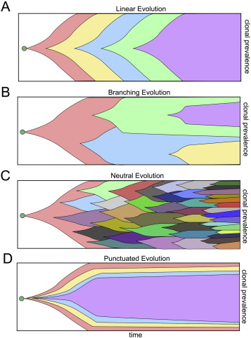

Recently, the punctuated evolution and the neutral evolution models have been appointed as the ones reflecting tumor heterogeneity the most, and have been confirmed on over 30% of TCGA Dataset. According to these models, a short burst of clones in the beginnig can turn into the expansion of some, and the co-existence of several branches at the same time. Also, the predominat clone can result either from the short, initial burst, or from subsiquently generated heterogeneity.

Heterogeneity can have different forms. The most widely observed is genetic heterogeneity, altough it only explains a small part of how tumor progresses in patients. The concept of the existence of persister cells, displaying non-genetic heterogeneity, is now something accepted and widely demonstrated [Huang S. et al](https://doi.org/10.1038/nrg2556). Since the large-scale diffusion of RNAsequencing technologies, a wide number of transcriptional classifiers have been investigated, as to try to predict, based on differential gene expression, the potential patient outcome or some features of the tumor. Among the most robust classifiers, we find examples such as the CRIS classifier for colorectal cancer [Isella et al.](https://doi.org/10.1038/ncomms15107), or PAM-50 classifier for breast cancer [Parker, J. S. et al.](https://doi.org/10.1200/jco.2008.18.1370)

Thanks to scRNAseq approaches, the occurrence of heterogeneusly classified cells inside the same tumor has been demonstrated. Combination of genetic, non genetic, aquired or pre-existing heterogeneity can give rise to a multitude of phenotypes, each with its own specific feature. However, another major source of intratumoral dishomogeneity can be appointed to features related to ECM and microenvironment components as well.

## 1.2 ECM heterogeneity

### 1.2.1 Its role in the tumoral landscape

Composition, posttranslational modifications, and organization of the ECM are dynamically regulated. Cells sense the biochemical and mechanical properties of the ECM through specialized transmembrane receptors that include integrins, discoidin domain receptors (DDRs), and syndecans.ECM composition, density, organization, and posttranslational modifications including cleavage and cross-linking dictate the material property or viscoelasticity, e.g., stiffness of the stroma. Biochemical and mechanical properties of the ECM exquisitely tune the growth, survival, migration, invasion, and differentiation of cells within the tissue to influence their fate and regulate tissue development, phenotype, and homeostasis. As a confirm of the importance of the characteristics of the ECM components, in most cancer types we can find some form of alteration of in organization or mechanical properties of ECM. This can lead to inflamation, fibroblast expansion and activation, angiogenesis disregulation and a stiff and crosslinked tumor stroma.

All of these processes directly ragulate tumor ability to grow, disseminate, extravasate and, eventually, metastatize. For example, a stiffened ECM has been related to a mechanical stress on the tumor cells which, while potentially interfering with tumor growth, increases the mechanical stress which in turn promotes EMT and a dysfunctional vasculature which facilitates intravasation Leventhal et al,Neve et al. The way in which this ECM disregulation happens are not yet fully understood. While several research focus on how cancer cells can directly influence tumoral microenvironment and EMT by secretion of proteins, the ability of ECM to signal and modify transcriptional profile of cells has to be taken into account as well. To support such observations, we find in literature many classifiers, which allow patient stratification trough molecular classifiers in which different subsets can be discriminated according o EMT related differentially expressed genes, such as the one published by [Peng Y. et al.](https://doi.org/10.3389%2Ffimmu.2021.666137)

Taking into account ECM features during the therapy decision making process, or even directly targetting ECM features could be new frontiers in cancer treatment. However, this requires a more in-depth investigation of regulation of ECM subtypes and the relative modulators, other than observing how intratumoral ECM heterogeneity contributes to the global characteristics of the tumor.

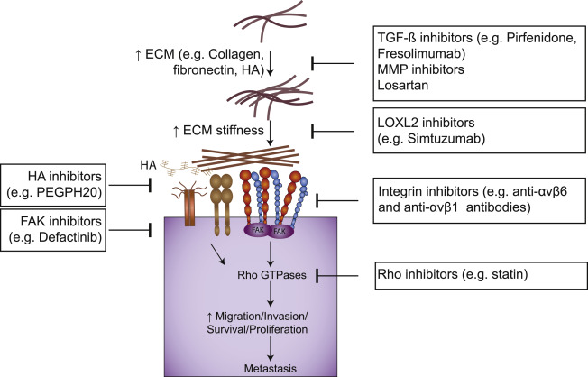

*Overview of Inhibitors that Perturb Cell-ECM Interactions and/or Adhesion Signaling that May Have Applications for the Treatment of Metastatic Cancers*

## 1.3 STIFmap project

In breast cancer, a stron g correlation has been found between extracellular matrix stiffening and invasiveness and aggressiveness of tumor. [Acerbi I. et al.](https://doi.org/10.1039/c5ib00040h) Nevertheless, classification of stiff regions in tumor samples proves to be difficult due to the elevated heterogeneity among the samples.

A general method to measure stiffness is the use of nanoscale Atomic Force Microscopy (AFM), a technique which measures elasticity of collagen fiber thanks to the measuremet of the occurring forces between the tip of the probe and the sample, calculated according to the tip deflection.

The analyzed dataset is part of a project carried out by UCSC surgery department, directed by Valerie M Weaver with the collaboration of Stashko C. and Northey J. Under the direction of Weaver V. surgery department, 3 patients of Breast cancer had their tumor collected and analyzed with STIFmap, a convolutional neural network.

Spatially Transformed Inferential Force Map (STIFMap) exploits computer vision to precisely automate atomic force microscopy (AFM) indentation combined with a trained convolutional neural network to predict stromal elasticity with micron-resolution using collagen morphological features and ground truth AFM data.

With this kind of technology,stromal stiffness can be measured and quantified on in-vivo tumors, investigating tumoral heterogeneity and the relationship with tumoral progression, in a visual way.

Classified tumor tissue was then collected and engrafted on a Patient derived xenograph (PDX). In this way, informations about tumor stiffness could be compared to RNAsequencing data, as to identify potential markers and features which could explain the observed differences from a molecular point of view, while also taking into account the intratumoral heterogeneity of each patient.

Resources and project description can also be found [here](https://www.ncbi.nlm.nih.gov/geo/query/acc.cgi).

# 2 Dataset features

## 2.1 Description

The GSE179983 dataset is available on [Gene Expression Omnibus (GEO)](https://www.ncbi.nlm.nih.gov/geo/query/acc.cgi?acc=GSE179983) database. It’s a serie of 18 human derived samples, engrafted into PDX. From each of the 3 patients enrolled in the STIFmap project at UCSC Weaver Lab, both stiff and soft tumor samples were collected, as to mantain the intratumoral heterogeneity features. Samples coming from the same patient but with different stromal composition were each split into 3 groups, as to generate 3 replicates, and each replicate was engrafted in a PDX, for a total of 6 PDX for patient, half with stiff stromal composition and half with a soft one.

The resulting 18 samples are part of the [GPL24676 platform](https://www.ncbi.nlm.nih.gov/geo/query/acc.cgi?acc=GPL24676). meaning they all were sequenced by High troughput Illumina NovaSeq 6000 for human samples, during the year 2018. RNAseq fastq files were mapped to the primary assembly of the Gencode v33 human genome using Rsubread (version 2.0.1) and counted using featureCounts, with Genome_build:hs33. RNA was isolated using TRIzol (Invitrogen, Cat. : 15596018) followed by chloroform extraction. RNAseq library preparation and sequencing was performed by the Vincent J. Coates Genomics Sequencing Laboratory, University of California, Berkeley. Samples were sequenced in NovaSeq 6000 S4 lanes with 150bp paired-end reads with approximately 25 million read pairs per sample Dataset is available as a raw count matrix, without any information regarding transcript length.

It can be downloaded and inspected as follows

## 2.2 Download and inspection

First, dataset is downloaded and unzipped

```r
setwd("Dataset/")
system("wget https://ftp.ncbi.nlm.nih.gov/geo/series/GSE179nnn/GSE179983/suppl/GSE179983_pdx_hs33_counts.txt.gz")
system("gunzip GSE179983_pdx_hs33_counts.txt.gz")
setwd("../")
```

This is required only when importing the dataset the first time and if the Dataset folder has not yet been downloaded. For this reason, in the script these lines have been commented

```r
cat(system("head Dataset/GSE179983_pdx_hs33_counts.txt",intern=TRUE),sep ='\n')
```

```
## ,B43104.R1.fastq.subread.BAM,B43202.R1.fastq.subread.BAM,B43203.R1.fastq.subread.BAM,B43204.R1.fastq.subread.BAM,B43303.R1.fastq.subread.BAM,B43304.R1.fastq.subread.BAM,B63703.R1.fastq.subread.BAM,B63704.R1.fastq.subread.BAM,B63705.R1.fastq.subread.BAM,B63801.R1.fastq.subread.BAM,B63802.R1.fastq.…
## ENSG00000223972.5,4,4,2,0,8,4,0,26,6,10,1,0,0,0,0,11,0,0
## ENSG00000227232.5,189,182,224,259,433,174,374,498,247,400,334,0,71,241,226,222,12,5
## ENSG00000278267.1,22,5,0,8,0,35,6,8,4,9,1,0,6,43,0,9,1,0
## ENSG00000243485.5,3,5,0,0,0,3,0,0,0,0,3,0,0,0,0,0,0,0
## ENSG00000284332.1,0,0,0,0,0,0,0,0,0,0,0,0,0,0,0,0,0,0
## ENSG00000237613.2,0,0,0,0,7,0,0,0,1,0,0,0,0,0,0,0,0,0
## ENSG00000268020.3,0,0,0,0,0,0,0,0,0,0,0,0,0,0,0,0,0,0
## ENSG00000240361.2,1,0,0,0,0,0,0,0,0,0,0,0,0,0,0,0,0,0
## ENSG00000186092.6,0,0,0,0,0,0,0,0,0,0,0,0,0,0,0,0,2,0
```

As we can see, the raw data counts are distribuited in 18 columns of a csv file. First column contains versioned Ensembl id of genes,first row contains the sample name. Column names correspond to BAM file names of each samples but are not representative of sample annotations. Annotations for each sample can be obtained from the collecion of [BioSamples accessions](https://www.ncbi.nlm.nih.gov/biosample?LinkName=bioproject_biosample_all&from_uid=746133) on NCBI database, for which a [summary](https://github.com/CBenetti/Data_Analysis_exam/blob/main/Dataset/GSE179983_biosample.txt) has been downloaded in txt format

```r
cat(system("head Dataset/GSE179983_biosample.txt",intern=TRUE),sep ='\n')
```

```
## 1. Breast tumor 2, stiff gel, rep3 [H12805]
## Identifiers: BioSample: SAMN20181906; SRA: SRS9465962; GEO: GSM5444459
## Organism:    Homo sapiens
## Accession: SAMN20181906  ID: 20181906
##
## 2. Breast tumor 3, stiff gel, rep2 [B43303]
## Identifiers: BioSample: SAMN20181905; SRA: SRS9465967; GEO: GSM5444464
## Organism:    Homo sapiens
## Accession: SAMN20181905  ID: 20181905
```

We can see here as each patient is associated to a tumor (tumor 1,2 or 3),each sample is either classified as stiff or soft, to annotate the results from STIFmap analysis, and different repliates are present for each patient tumor type.

## 2.3 Dataset processing

As to procede into further analysis of the data, the Geneset must be loaded into R environment, annotations should be integrated in a was as to match the original sample set, Gene names attribuited to each Ensembl id, and counts normalized. Each of these results is produced by sourcing the [import script](https://github.com/CBenetti/Data_Analysis_exam/blob/main/Scripts/01_import.R) from the main folder in R.

```r
source("Scripts/01_import.R")
```

```
## snapshotDate(): 2022-10-31
```

```
## loading from cache
```

The starting point is the DataFrame ds, loaded in R environment as

```r
ds <- read.table("Dataset/GSE179983_pdx_hs33_counts.txt", sep=",", header=T, row.names=1)
dim(ds)
```

```
## [1] 60721    18
```

```r
head(ds)
```

```
##                   B43104.R1.fastq.subread.BAM B43202.R1.fastq.subread.BAM
## ENSG00000223972.5                           4                           4
## ENSG00000227232.5                         189                         182
## ENSG00000278267.1                          22                           5
## ENSG00000243485.5                           3                           5
## ENSG00000284332.1                           0                           0
## ENSG00000237613.2                           0                           0
##                   B43203.R1.fastq.subread.BAM B43204.R1.fastq.subread.BAM
## ENSG00000223972.5                           2                           0
## ENSG00000227232.5                         224                         259
## ENSG00000278267.1                           0                           8
## ENSG00000243485.5                           0                           0
## ENSG00000284332.1                           0                           0
## ENSG00000237613.2                           0                           0
##                   B43303.R1.fastq.subread.BAM B43304.R1.fastq.subread.BAM
## ENSG00000223972.5                           8                           4
## ENSG00000227232.5                         433                         174
## ENSG00000278267.1                           0                          35
## ENSG00000243485.5                           0                           3
## ENSG00000284332.1                           0                           0
## ENSG00000237613.2                           7                           0
##                   B63703.R1.fastq.subread.BAM B63704.R1.fastq.subread.BAM
## ENSG00000223972.5                           0                          26
## ENSG00000227232.5                         374                         498
## ENSG00000278267.1                           6                           8
## ENSG00000243485.5                           0                           0
## ENSG00000284332.1                           0                           0
## ENSG00000237613.2                           0                           0
##                   B63705.R1.fastq.subread.BAM B63801.R1.fastq.subread.BAM
## ENSG00000223972.5                           6                          10
## ENSG00000227232.5                         247                         400
## ENSG00000278267.1                           4                           9
## ENSG00000243485.5                           0                           0
## ENSG00000284332.1                           0                           0
## ENSG00000237613.2                           1                           0
##                   B63802.R1.fastq.subread.BAM B63803.R1.fastq.subread.BAM
## ENSG00000223972.5                           1                           0
## ENSG00000227232.5                         334                           0
## ENSG00000278267.1                           1                           0
## ENSG00000243485.5                           3                           0
```

[output cut: 8 more lines]

```
## ENSG00000237613.2                           0                           0
##                   H12703.R1.fastq.subread.BAM H12802.R1.fastq.subread.BAM
## ENSG00000223972.5                           0                          11
## ENSG00000227232.5                         226                         222
## ENSG00000278267.1                           0                           9
## ENSG00000243485.5                           0                           0
## ENSG00000284332.1                           0                           0
## ENSG00000237613.2                           0                           0
##                   H12804.R1.fastq.subread.BAM H12805.R1.fastq.subread.BAM
## ENSG00000223972.5                           0                           0
## ENSG00000227232.5                          12                           5
## ENSG00000278267.1                           1                           0
## ENSG00000243485.5                           0                           0
## ENSG00000284332.1                           0                           0
## ENSG00000237613.2                           0                           0
```

The raw count table is to be considered a Dataframe with 18 columns and 60721 rowns, corresponding to the 18 samples and with a total of 60721 mapped ids.

To assign annotation to each sample, the following pece of code is used to read lines of the annotation file, match the sample name to the correct line, and then deconstruct it to get information about the patient, the stromal stiffnes and the replicate.

```r
##phenoData annotation

pd <- readLines("Dataset/GSE179983_biosample.txt")
pd<-pd[seq(1,90,5)]
tumor <- unlist(lapply(pd,function(x){strsplit(strsplit(x,"Breast ")[[1]][2],", ")[[1]][1]}))
tumor <- gsub(" ","",tumor)
stroma <- unlist(lapply(pd,function(x){strsplit(strsplit(x,", ")[[1]][2]," gel")[[1]][1]}))
tmp <- unlist(lapply(pd,function(x){gsub("\\]","",strsplit(x,", ")[[1]][3])}))
name <- unlist(lapply(tmp, function(x){strsplit(x," \\[")[[1]][2]}))
rep <- unlist(lapply(tmp, function(x){strsplit(x," \\[")[[1]][1]}))
phenoD <- data.frame(stroma=factor(stroma),patient=factor(tumor),replicate=factor(rep))
rownames(phenoD) <- name
colnames(ds) <- unlist(lapply(colnames(ds),function(x){strsplit(x,"\\.")[[1]][1]}))
phenoD <- phenoD[colnames(ds),]
phenoD
```

```
##        stroma patient replicate
## B43104  stiff  tumor3      rep1
## B43202   soft  tumor3      rep1
## B43203   soft  tumor3      rep2
## B43204   soft  tumor3      rep3
## B43303  stiff  tumor3      rep2
## B43304  stiff  tumor3      rep3
## B63703   soft  tumor1      rep1
## B63704   soft  tumor1      rep2
## B63705   soft  tumor1      rep3
## B63801  stiff  tumor1      rep1
## B63802  stiff  tumor1      rep2
## B63803  stiff  tumor1      rep3
## H12701   soft  tumor2      rep1
## H12702   soft  tumor2      rep2
## H12703   soft  tumor2      rep3
## H12802  stiff  tumor2      rep1
## H12804  stiff  tumor2      rep2
## H12805  stiff  tumor2      rep3
```

We can see that now, annotations match the sample names in the column of the dataframe

```r
colnames(ds)
```

```
##  [1] "B43104" "B43202" "B43203" "B43204" "B43303" "B43304" "B63703" "B63704"
##  [9] "B63705" "B63801" "B63802" "B63803" "H12701" "H12702" "H12703" "H12802"
## [17] "H12804" "H12805"
```

### 2.3.1 Recovery of Gene names

This is important to allow the correct interpretation of the final results. Converting each Ensembl id into Gene names is possible thanks to the Bioconductor package [ensembldb](https://bioconductor.org/packages/release/bioc/html/ensembldb.html), in which a filter framework can be used to retrieve annotations from Ensembl database. To download the correct version of the Ensembldb, the package [AnnotationHub](https://bioconductor.org/packages/release/bioc/html/AnnotationHub.html) was used The genome build used to map fastq files was Gencode v33, which corresponds to [GRCh38.p13](https://www.gencodegenes.org/human/release_33.html) assembly.

According to [Ensembl assembly specifics](https://www.ensembl.org/info/website/archives/assembly.html), GRCh38.p13 is covered by Ensembl versions spanning from 98 to 109. V99 was chosen for this project.

All of the packages required for the analysis are already installed in the docker, as per the instructions on the Dockerfile Informations on how to build, download or use the docker can be found on the Docker folder on github, and more detailed instructions are provided in the relative README.md file.

With the following code, after the library loading the download of the Ensembldb takes place. Since the download is done automatically inside the R cache folder, this has to be created first, acoording to the architecture in use.

```r
library(ensembldb)
library(AnnotationHub)
#Download an annotation version compatible with Genome assembly hs33
        if(!file.exists(getAnnotationHubOption("CACHE"))){
                here<-getwd()
                setwd("~")
                home <- unlist(strsplit(getwd(),"/"))
                obj <- unlist(strsplit(getAnnotationHubOption("CACHE"),"/"))
                abs <- obj[which(match(obj,home, nomatch=0)==0)]
                for(i in 1:length(abs)){dir<-paste(abs[c(1:i)],collapse="/");if(!file.exists(dir)){dir.create(dir)}}
                setwd(here)
        }
        ah <- AnnotationHub()
```

```
## snapshotDate(): 2022-10-31
```

```r
        ahDb <- query(ah, pattern = c("Homo Sapiens", "EnsDb", 99))
        ahEdb <- ahDb[[1]]
```

```
## loading from cache
```

```r
genes(ahEdb)
```

```
## GRanges object with 67998 ranges and 8 metadata columns:
##                   seqnames            ranges strand |         gene_id
##                      <Rle>         <IRanges>  <Rle> |     <character>
##   ENSG00000223972        1       11869-14409      + | ENSG00000223972
##   ENSG00000227232        1       14404-29570      - | ENSG00000227232
##   ENSG00000278267        1       17369-17436      - | ENSG00000278267
##   ENSG00000243485        1       29554-31109      + | ENSG00000243485
##   ENSG00000284332        1       30366-30503      + | ENSG00000284332
##               ...      ...               ...    ... .             ...
##   ENSG00000224240        Y 26549425-26549743      + | ENSG00000224240
##   ENSG00000227629        Y 26586642-26591601      - | ENSG00000227629
##   ENSG00000237917        Y 26594851-26634652      - | ENSG00000237917
##   ENSG00000231514        Y 26626520-26627159      - | ENSG00000231514
##   ENSG00000235857        Y 56855244-56855488      + | ENSG00000235857
##                     gene_name           gene_biotype seq_coord_system
##                   <character>            <character>      <character>
##   ENSG00000223972     DDX11L1 transcribed_unproces..       chromosome
##   ENSG00000227232      WASH7P unprocessed_pseudogene       chromosome
##   ENSG00000278267   MIR6859-1                  miRNA       chromosome
##   ENSG00000243485 MIR1302-2HG                 lncRNA       chromosome
##   ENSG00000284332   MIR1302-2                  miRNA       chromosome
##               ...         ...                    ...              ...
##   ENSG00000224240     CYCSP49   processed_pseudogene       chromosome
##   ENSG00000227629  SLC25A15P1 unprocessed_pseudogene       chromosome
##   ENSG00000237917     PARP4P1 unprocessed_pseudogene       chromosome
##   ENSG00000231514      CCNQP2   processed_pseudogene       chromosome
##   ENSG00000235857     CTBP2P1   processed_pseudogene       chromosome
##                              description   gene_id_version      symbol entrezid
##                              <character>       <character> <character>   <list>
##   ENSG00000223972 DEAD/H-box helicase .. ENSG00000223972.5     DDX11L1     <NA>
##   ENSG00000227232 WASP family homolog .. ENSG00000227232.5      WASH7P     <NA>
##   ENSG00000278267 microRNA 6859-1 [Sou.. ENSG00000278267.1   MIR6859-1     <NA>
##   ENSG00000243485 MIR1302-2 host gene .. ENSG00000243485.5 MIR1302-2HG     <NA>
##   ENSG00000284332 microRNA 1302-2 [Sou.. ENSG00000284332.1   MIR1302-2     <NA>
##               ...                    ...               ...         ...      ...
##   ENSG00000224240 CYCS pseudogene 49 [.. ENSG00000224240.1     CYCSP49     <NA>
##   ENSG00000227629 solute carrier famil.. ENSG00000227629.1  SLC25A15P1     <NA>
##   ENSG00000237917 poly(ADP-ribose) pol.. ENSG00000237917.1     PARP4P1     <NA>
##   ENSG00000231514 CCNQ pseudogene 2 [S.. ENSG00000231514.1      CCNQP2     <NA>
##   ENSG00000235857 CTBP2 pseudogene 1 [.. ENSG00000235857.1     CTBP2P1     <NA>
##   -------
##   seqinfo: 454 sequences (1 circular) from GRCh38 genome
```

The genes() function can be used to visualize the fields of the object. Our main fields of interest are the gene_id_version, which corresponds to the versioned Ensembl ids provided in the raw data table, symbols and gene_biotype.

> **NOTE** When downloading the database for the first time, it might require some time. To shorten the rendering time, sourcing code 01_import.R before rendering would allow to retrieve the files from cache when executing the render() function

Usually, the query of the ahEdb objec is done trough filtering for de-versioned id. However, since here we dispose of versioned ids, which have the advantage of being univoque, an alternative procedure was put in place to obtain information directly from gene_id_version, altough it isn’t available as a filter. Also, we should consider that the ahEdb object is not a dataframe, and thus it should not be subsetted as such. First, we check wether there are any unmapped ids.

```r
rownames(ds)[which(match(rownames(ds),genes(ahEdb)$gene_id_version,nomatch=0)==0)]
```

```
##  [1] "ENSG00000228572.7_PAR_Y"  "ENSG00000182378.14_PAR_Y"
##  [3] "ENSG00000178605.13_PAR_Y" "ENSG00000226179.6_PAR_Y"
##  [5] "ENSG00000167393.18_PAR_Y" "ENSG00000281849.3_PAR_Y"
##  [7] "ENSG00000275287.5_PAR_Y"  "ENSG00000280767.3_PAR_Y"
##  [9] "ENSG00000234958.6_PAR_Y"  "ENSG00000229232.6_PAR_Y"
## [11] "ENSG00000185960.14_PAR_Y" "ENSG00000237531.6_PAR_Y"
## [13] "ENSG00000225661.7_PAR_Y"  "ENSG00000205755.12_PAR_Y"
## [15] "ENSG00000198223.16_PAR_Y" "ENSG00000265658.6_PAR_Y"
## [17] "ENSG00000223274.6_PAR_Y"  "ENSG00000185291.12_PAR_Y"
## [19] "ENSG00000169100.14_PAR_Y" "ENSG00000236871.7_PAR_Y"
## [21] "ENSG00000236017.8_PAR_Y"  "ENSG00000169093.16_PAR_Y"
## [23] "ENSG00000182162.11_PAR_Y" "ENSG00000197976.12_PAR_Y"
## [25] "ENSG00000196433.13_PAR_Y" "ENSG00000223511.7_PAR_Y"
## [27] "ENSG00000234622.6_PAR_Y"  "ENSG00000169084.15_PAR_Y"
## [29] "ENSG00000223571.6_PAR_Y"  "ENSG00000214717.12_PAR_Y"
## [31] "ENSG00000277120.5_PAR_Y"  "ENSG00000223773.7_PAR_Y"
## [33] "ENSG00000230542.6_PAR_Y"  "ENSG00000002586.20_PAR_Y"
## [35] "ENSG00000168939.11_PAR_Y" "ENSG00000237801.6_PAR_Y"
## [37] "ENSG00000237040.6_PAR_Y"  "ENSG00000124333.16_PAR_Y"
## [39] "ENSG00000228410.6_PAR_Y"  "ENSG00000223484.7_PAR_Y"
## [41] "ENSG00000124334.17_PAR_Y" "ENSG00000270726.6_PAR_Y"
## [43] "ENSG00000185203.12_PAR_Y" "ENSG00000182484.15_PAR_Y"
## [45] "ENSG00000227159.8_PAR_Y"
```

Unmatching ids are related to ids for which _PAR_Y suffix was applied. According to Ensembl database, the IDs with _PAR_Y suffix do not exist, but they seem to be related to pseudoautosoomal genes, thus genes related to X and Y chromosomes, which can be aligned to both as a result of their proximity to crossing over hotspots. By defaul, in ensembldb such genes are aligned to X chromosome. As a matter of fact, ids without the suffix are already present in the geneset and can be ascribed to regions on the X chromosomes.

```r
        tmp <- unlist(lapply(rownames(ds)[which(match(rownames(ds),genes(ahEdb)$gene_id_version,nomatch=0)==0)],function(x){strsplit(x,"_")[[1]][1]}))
        tmp%in%rownames(ds)
```

```
##  [1] TRUE TRUE TRUE TRUE TRUE TRUE TRUE TRUE TRUE TRUE TRUE TRUE TRUE TRUE TRUE
## [16] TRUE TRUE TRUE TRUE TRUE TRUE TRUE TRUE TRUE TRUE TRUE TRUE TRUE TRUE TRUE
## [31] TRUE TRUE TRUE TRUE TRUE TRUE TRUE TRUE TRUE TRUE TRUE TRUE TRUE TRUE TRUE
```

As to not completely exclude them from the analysis, symbols are assigned on the base of the X aligned id, excluding the suffix from the query for the subset of unmatching genes

```r
        Tx <- vector(length=length(rownames(ds)))
        biotype <- vector(length=length(rownames(ds)))
        names(Tx) <- rownames(ds)
        names(biotype) <- rownames(ds)

        #Assigning symbols for Id's which match
        main <- genes(ahEdb)[which(match(genes(ahEdb)$gene_id_version,rownames(ds)[which(match(rownames(ds),genes(ahEdb)$gene_id_version,nomatch=0)>0)],nomatch=0)>0)]
        ids <- as.vector(main$gene_id_version)
        sym <- as.vector(main$symbol)
        Tx[ids] <- sym
        bio <- as.vector(main$gene_biotype)
        biotype[ids] <- bio

        #Assigning symbols for IDs which don't
        main <- genes(ahEdb)[which(match(genes(ahEdb)$gene_id_version,tmp,nomatch=0)>0)]
        ids <- as.vector(main$gene_id_version)
        sym <- as.vector(main$symbol)
        sym <- unlist(lapply(sym, function(x){paste(c(x,"_PAR_Y"),collapse="")}))
    ids <- unlist(lapply(ids, function(x){paste(c(x,"_PAR_Y"),collapse="")}))
        Tx[ids] <- sym
        bio <- as.vector(main$gene_biotype)
        biotype[ids] <- bio
        names(biotype) <- NULL
        names(Tx)<- NULL
```

At this point, Tx contains the gene symbols associated to the ensemblids in the rownames of the dataset

```r
head(Tx)
```

```
## [1] "DDX11L1"     "WASH7P"      "MIR6859-1"   "MIR1302-2HG" "MIR1302-2"
## [6] "FAM138A"
```

```r
head(rownames(ds))
```

```
## [1] "ENSG00000223972.5" "ENSG00000227232.5" "ENSG00000278267.1"
## [4] "ENSG00000243485.5" "ENSG00000284332.1" "ENSG00000237613.2"
```

To identify the presence of duplicated genes, the following lines of code retrieve the position of duplicated symbols and uses the corresponding ids to retrieve information on said genes, which is then saved. in this way, we can procede with the analysis with the totality of the genes, and only filtering them out in case they appear as differentially expressed.

```r
        #Info on duplicated symbols
        dup <- Tx[which(duplicated(Tx)==TRUE)]
        info_on_duplicated_id <- genes(ahEdb)[which(match(genes(ahEdb)$gene_id_version,rownames(ds)[ which(Tx%in%dup ==TRUE)],nomatch=0)>0),]
        save(info_on_duplicated_id,file="Results/Duplicated_id_info.rda")

length(Tx[which(duplicated(Tx)==TRUE)])
```

```
## [1] 34
```

```r
head(info_on_duplicated_id)
```

```
## GRanges object with 6 ranges and 8 metadata columns:
##                   seqnames              ranges strand |         gene_id
##                      <Rle>           <IRanges>  <Rle> |     <character>
##   ENSG00000274582        1   28580920-28581056      - | ENSG00000274582
##   ENSG00000280498        1   28580920-28581054      - | ENSG00000280498
##   ENSG00000207421        1   44778390-44778456      + | ENSG00000207421
##   ENSG00000281859        1   44778390-44778458      + | ENSG00000281859
##   ENSG00000280466        1 155925958-155926085      - | ENSG00000280466
##   ENSG00000281394        1 155925958-155926086      - | ENSG00000281394
##                     gene_name gene_biotype seq_coord_system
##                   <character>  <character>      <character>
##   ENSG00000274582    SNORA16A       snoRNA       chromosome
##   ENSG00000280498    SNORA16A       snoRNA       chromosome
##   ENSG00000207421    SNORD38B       snoRNA       chromosome
##   ENSG00000281859    SNORD38B       snoRNA       chromosome
##   ENSG00000280466     SCARNA4       scaRNA       chromosome
##   ENSG00000281394     SCARNA4       scaRNA       chromosome
##                              description   gene_id_version      symbol entrezid
##                              <character>       <character> <character>   <list>
##   ENSG00000274582 small nucleolar RNA,.. ENSG00000274582.1    SNORA16A     <NA>
##   ENSG00000280498 small nucleolar RNA,.. ENSG00000280498.1    SNORA16A     <NA>
##   ENSG00000207421 small nucleolar RNA,.. ENSG00000207421.1    SNORD38B     <NA>
##   ENSG00000281859 small nucleolar RNA,.. ENSG00000281859.1    SNORD38B     <NA>
##   ENSG00000280466 small Cajal body-spe.. ENSG00000280466.1     SCARNA4     <NA>
##   ENSG00000281394 small Cajal body-spe.. ENSG00000281394.1     SCARNA4     <NA>
##   -------
##   seqinfo: 454 sequences (1 circular) from GRCh38 genome
```

As we can see, duplicated genes are only 34, and they mainly display differences in the starting or ending position

### 2.3.2 ExpressionSet initialization

The ExpressionSet to be submitted for further analyis was initialized with [Biobase](http://bioconductor.org/packages/release/bioc/html/Biobase.html) tools. A total of 3 Expressionset was built, one for the raw counts, one for the cpm normalized counts and one for the log2 normalized counts, obtained as follows

```r
library(edgeR)
counts <- cpm(ds)
logcounts <- cpm(ds,prior.count=1,log=TRUE)
```

```r
library(Biobase)

        minimalSet <- ExpressionSet(assayData=as.matrix(ds))
        phenoData(minimalSet) <- new("AnnotatedDataFrame",data=phenoD)
        featureData(minimalSet) <- new("AnnotatedDataFrame",data=data.frame(Geneid=Tx, Biotype=biotype))
        counts <- cpm(ds)
        logcounts <- log(counts+1,2)
        countset <- ExpressionSet(assayData=as.matrix(counts))
        phenoData(countset) <- new("AnnotatedDataFrame",data=phenoD)
        featureData(countset) <- new("AnnotatedDataFrame",data=data.frame(Geneid=Tx,Biotype=biotype))
        logc <- ExpressionSet(assayData=as.matrix(logcounts))
        phenoData(logc) <- new("AnnotatedDataFrame",data=phenoD)
        featureData(logc) <- new("AnnotatedDataFrame",data=data.frame(Geneid=Tx,Biotype=biotype))

        GSE179983 <- list(minimal = minimalSet,count = countset, log = logc)
    save(GSE179983, file="Dataset/GSE179983.rda")

GSE179983$count
```

```
## ExpressionSet (storageMode: lockedEnvironment)
## assayData: 60721 features, 18 samples
##   element names: exprs
## protocolData: none
## phenoData
##   rowNames: B43104 B43202 ... H12805 (18 total)
##   varLabels: stroma patient replicate
##   varMetadata: labelDescription
## featureData
##   featureNames: 1 2 ... 60721 (60721 total)
##   fvarLabels: Geneid Biotype
##   fvarMetadata: labelDescription
## experimentData: use 'experimentData(object)'
## Annotation:
```

```r
pData(GSE179983$count)
```

```
##        stroma patient replicate
## B43104  stiff  tumor3      rep1
## B43202   soft  tumor3      rep1
## B43203   soft  tumor3      rep2
## B43204   soft  tumor3      rep3
## B43303  stiff  tumor3      rep2
## B43304  stiff  tumor3      rep3
## B63703   soft  tumor1      rep1
## B63704   soft  tumor1      rep2
## B63705   soft  tumor1      rep3
## B63801  stiff  tumor1      rep1
## B63802  stiff  tumor1      rep2
## B63803  stiff  tumor1      rep3
## H12701   soft  tumor2      rep1
## H12702   soft  tumor2      rep2
## H12703   soft  tumor2      rep3
## H12802  stiff  tumor2      rep1
## H12804  stiff  tumor2      rep2
## H12805  stiff  tumor2      rep3
```

```r
dim(fData(GSE179983$count))
```

```
## [1] 60721     2
```

```r
head(fData(GSE179983$count))
```

```
##        Geneid                            Biotype
## 1     DDX11L1 transcribed_unprocessed_pseudogene
## 2      WASH7P             unprocessed_pseudogene
## 3   MIR6859-1                              miRNA
## 4 MIR1302-2HG                             lncRNA
## 5   MIR1302-2                              miRNA
## 6     FAM138A                             lncRNA
```

With this set of data, it is possible to procede to the analyisis on the differential gene expression between samples with different stromal stiffness and evaluate the impact of intratumoral heterogeneity on the results.

# 3 Results

The overall design of the analysis involves a differential expression analysis between stromal stiff and stromal soft tumors, in order to understand whether there is any driver or effector which triggers or has been triggered from the different environments in which cells are embedded. A biological investigation of the results completes the picture, as to investigate biological processes which may be involved in the differential stromal composition, but also to evaluate if our experimental design had any biological coherence at all. Results for each step of the analysis were saved as pdf images in the Results folder in the Github repository, by means of pdf calling before plot generation in each of the R script.

> **Example**

```r
pdf("Results/plot.pdf")

#image or plot generation

dev.off()
```

## 3.1 Data visualization and dimensional reduction

Since we are considering an expressionset with more than 60000 features, dimensional reduction is required to visualize the data and allow to make observations on the dataset before performing any analysis. For this reason, a comparison between a pca and tsne plot seemed as the most reasonable approach. Analysis can be run by sourcing 02_dimensional_reduction_plot.R file from the Data_analysis_exam folder.

```r
source("Scripts/02_dimensional_reduction_plot.R")
```

### 3.1.1 PCA

PCA is the most informative dimensonal reduction technique, allowing to make observations according on the amount of variance explained by each of the components. In this kind of graph, the spread along the axis with the higher variance explained is representative of the highest source of variability between samples. We can hence try to propose a biological interpretation on the basis of the annotation data associated to each sample.

For the analysis, the prcomp function is used, and since it’s already present in the R base pool of function, no additional package has to be loaded from our library.

The expressionset in use for the dimenctional reduction refers to normalized and logaritmic form of the data, as per the requirements of the function. Data must be transposed, as we want to perform reduction on genes, as to represent each sample as a point in a bidimensional space. This is true for both tsne and pca

```r
library(Biobase)
load("Dataset/GSE179983.rda")
```

```r
pca <- prcomp(t(exprs(GSE179983$log)))
```

From the Scree plot of the explained variance, we understand how much variance is explained by each component. A succesful PCA should have an exponential decrease in the variance explained by each successive component.

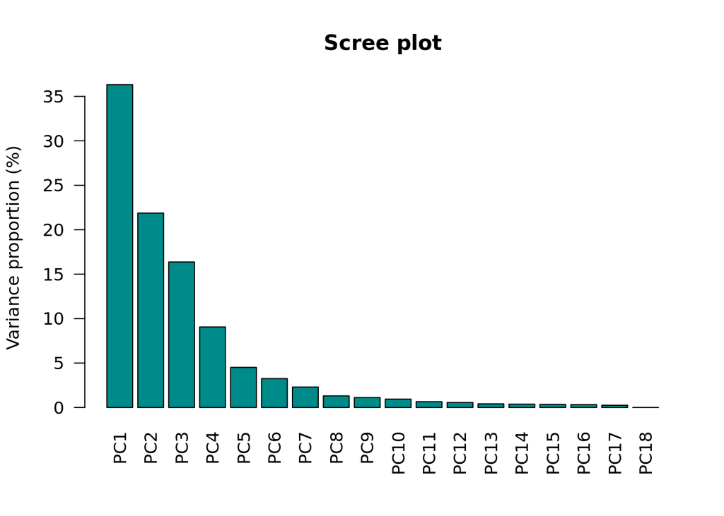

```r
x <- factor(colnames(summary(pca)$importance), levels=colnames(summary(pca)$importance))
barplot(summary(pca)$importance[2,]*100,names.arg=x, las=2, ylab="Variance proportion (%)", main="Scree plot", col="darkcyan")
```

From this Scree plot, a significative reduction of explained variance can be observed, with little to no variance explained after PC10. The amount of variance explained by ther first principal component however does not reach 40%, suggesting a somehow complex picture.

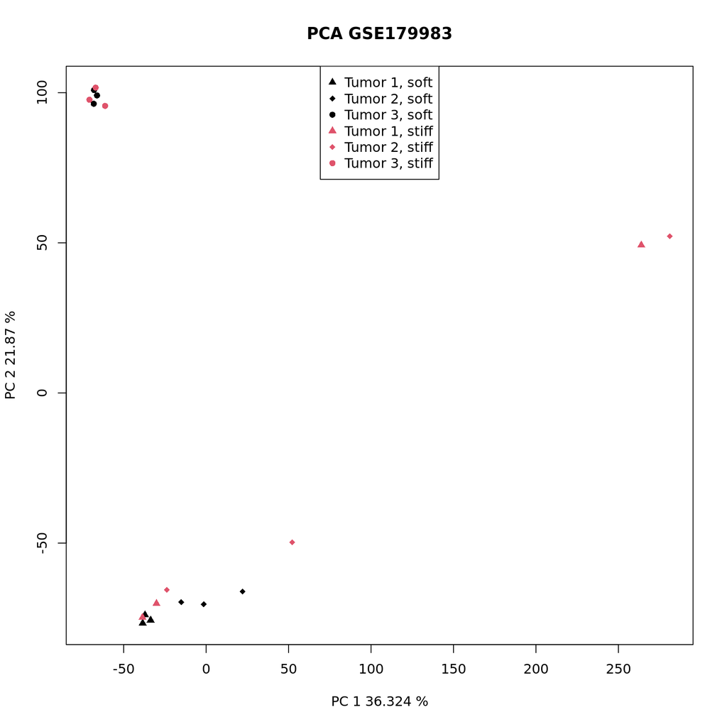

```r
plot(pca$x[,1],pca$x[,2], col=pData(GSE179983$log)$stroma,pch=c(rep(16,6),rep(17,6),rep(18,6)),xlab=paste(c("PC 1",summary(pca)$importance[2,1]*100,"%"),collapse=" "), ylab =paste(c("PC 2",summary(pca)$importance[2,2]*100,"%"),collapse=" "), main="PCA GSE179983")
legend("top",col=c(rep(1,3),rep(2,3)),pch=rep(c(17,18,16),2), legend = c("Tumor 1, soft","Tumor 2, soft","Tumor 3, soft","Tumor 1, stiff","Tumor 2, stiff","Tumor 3, stiff"))
```

The plot provides functional annotations regarding the stromal type and the patient from which samples were collected. There is a distinct separations between samples from patient 3 and all others, suggesting this patient could hold some heterogeneity features which distingush him from all others. Also, the biggest separation occurs for a couple of stromal stiff samples, either pointing them out as outliers or due to a greater similarity in the mechanisms in which stromal stiffnes was achieved. Overall, no clear separation between stromal stiff and stromal soft sample could be observed.

### 3.1.2 tsne

To better focus on the grouping and similarities within samples, tsne dimensional reduction was employed. Rtsne packege for R is required In this case, we cannot get informations on how the variance is spread, however we can have a greater insight on how much samples are similar between each other. To exclude variability associated to random number generation, seed was randomly set to allow for reproducibility. Perplexity, the abiliy of a tsne to try and capture the bigger picture behind the distribution of the data, was set to 5, as the optimal range for perplexity should be between 5 and 50, and given the low dimensionality of our dataset, 5 is close to the maximum perplexity allowed for the system

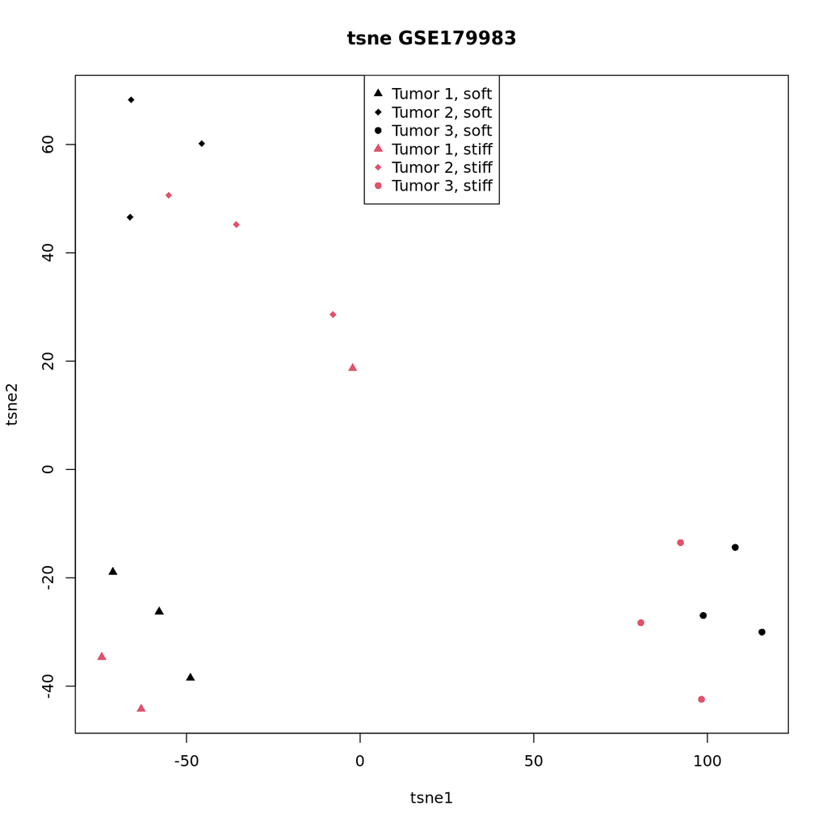

```r
set.seed(666)
tsne <- Rtsne(t(exprs(GSE179983$log)), perplexity=5)
plot(tsne$Y[,1],tsne$Y[,2], col=pData(GSE179983$log)$stroma,pch=c(rep(16,6),rep(17,6),rep(18,6)),xlab="tsne1", ylab ="tsne2", main="tsne GSE179983")
legend("top",col=c(rep(1,3),rep(2,3)),pch=rep(c(17,18,16),2), legend = c("Tumor 1, soft","Tumor 2, soft","Tumor 3, soft","Tumor 1, stiff","Tumor 2, stiff","Tumor 3, stiff"))
```

In tsne, we can see better how samples tend to cluster according to the patient, rather than for the stromal composition. Again, patient 1 and 2 seem to share more similarty as they are closer, however with tsne we better evaluate similarity than distance, so we have no information on how different are elements which are more distant. Again, two samples from stromal stiff tumors of patient 1 and 2 seem to display a closer similarity. With tsne, we can also observe how within each cluster, some sort of separation between stromal stiff and soft tumors exists. However, differences among patients seem to prevaricate over differences in stromal stiffness. Thus, when performing differential expression analysis, these things should be accounted for in the design formula.

## 3.2 Differential expression analysis

Diffrential expression can be performed by sourcing 03_differential_expression.R.

### 3.2.1 Differential gene expression

For the differential expression analysis, [DESeq2](http://bioconductor.org/packages/devel/bioc/vignettes/DESeq2/inst/doc/DESeq2.html) package is used. During a differential expression analysis, differentially expressed genes are found according to a glm model. In this case, the model has to take into account both the condition of interest (stromal stiffnes vs stromal softness) and the patient from which the sample has been collected, to account from batch effect due to the patient.

For this kind of analysis, the raw data format is required, since the function already filters and normalized the data by setting a minimum level of expression and normalizing for sequencing depth (lib.size).

```r
###library
        library(edgeR)
        library(Biobase)
    library(DESeq2)
    dds <- DESeqDataSetFromMatrix(countData = exprs(GSE179983$minimal), colData = data.frame(condition=pData(GSE179983$minimal)$stroma,group=pData(GSE179983$minimal)$patient),design = ~ group + condition )
```

The first step is to create a DESeq2 object, which is fit for the analyisis. In this object, we also specify the formula of the design. In the formula, group stands for the patient of appartenence. Putting this term as first, as suggested by DESeq2 guidelines, allows to build a background encompassing all the differences between each patient and than creating a baseline. The second term is the the condition of interest. In the Expressionset structure, pData was already initialized as a factor, which is the form in which these annotations should be used in the formula, to be used in a logistic regression.

The DESeq2 object is then used for the analysis.

```r
        res <- DESeq(dds)
    summary(results(res))
```

```
##
## out of 45558 with nonzero total read count
## adjusted p-value < 0.1
## LFC > 0 (up)       : 581, 1.3%
## LFC < 0 (down)     : 5, 0.011%
## outliers [1]       : 917, 2%
## low counts [2]     : 19603, 43%
## (mean count < 3)
## [1] see 'cooksCutoff' argument of ?results
## [2] see 'independentFiltering' argument of ?results
```

Criteria for filtering have been developed also on the basis of the distribution of the logFC over the gene mean expression values. Genes which have an expression of 0 or close to it, display an high LogFC in function of the fact that dividing by zero in a logaritm provides very high value, in spite of an actual significative differential expression.

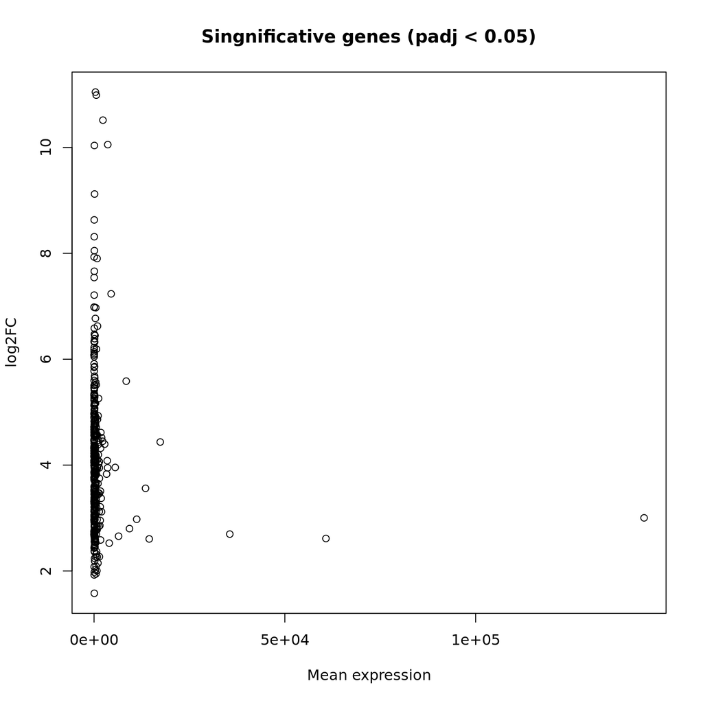

```r
        plot(results(res)$baseMean[which(results(res)$padj<0.05)],results(res)$log2FoldChange[which(results(res)$padj<0.05)],xlab="Mean expression",ylab="log2FC",main="Singnificative genes (padj < 0.05)")
```

From the distribution of genes with a padj < 0.05, we see that all of the genes have a LogFC > 0. We also see that most of them have a mean expression close to 0.

[figure not shown]

```r
    plot(results(res)$baseMean[which(results(res)$padj<0.05)],results(res)$log2FoldChange[which(results(res)$padj<0.05)],xlim=c(0,1000),xlab="Mean expression",ylab="log2FC",main="Singnificative genes (padj < 0.05)")
        abline(v=quantile(results(res)$baseMean,seq(0,1,0.05))[20], col="blue")
        abline(v=quantile(results(res)$baseMean,seq(0,1,0.05))[18], col="yellow")
        abline(v=quantile(results(res)$baseMean,seq(0,1,0.05))[17], col="green")
        abline(v=quantile(results(res)$baseMean,seq(0,1,0.05))[16], col="red")
        legend("top","left",pch=16,col=c("blue","yellow","green","red"),legend=c("90%","85%","80%","75%"))
```

Zooming in the region close to 0, we can better see the distribution of the genes. Different cutoffs can be chosen according to the distribution of the mean around different quantiles. 75% quantile seems as the most conservative choice but strict enough as to be able to exclude genes with mean too close to 0.

According to this distribution, genes with LogFC>3, padj<0.05 and mean expression higher than 75 percentile were considered as differentially expressed

```r
        higher_in_stiff <- rownames(results(res))[which(results(res)$padj < 0.05 & results(res)$log2FoldChange > 3 & results(res)$baseMean>quantile(results(res)$baseMean,probs=seq(0,1,0.05))[16])]
        red <- exprs(GSE179983$log)[higher_in_stiff,]
        hstiff <- fData(GSE179983$log)$Geneid[which(match(rownames(exprs(GSE179983$log)),higher_in_stiff,nomatch=0)>0)]
```

We can than make sure that among the differentially expressed genes there are none of those with duplicated symbols

```r
unique(unlist(info_on_duplicated_id$symbol))%in%hstiff
```

```
##  [1] FALSE FALSE FALSE FALSE FALSE FALSE FALSE FALSE FALSE FALSE FALSE FALSE
## [13] FALSE FALSE FALSE FALSE FALSE FALSE FALSE FALSE FALSE FALSE FALSE FALSE
## [25] FALSE FALSE FALSE FALSE FALSE FALSE FALSE FALSE FALSE FALSE
```

Also, none of the differentially expressed gene is among the list of pseudoautosomal genes.

```r
tmp <- unlist(lapply(rownames(ds)[which(match(rownames(ds),genes(ahEdb)$gene_id_version,nomatch=0)==0)],function(x){strsplit(x,"_")[[1]][1]}))
tmp%in%hstiff
```

```
##  [1] FALSE FALSE FALSE FALSE FALSE FALSE FALSE FALSE FALSE FALSE FALSE FALSE
## [13] FALSE FALSE FALSE FALSE FALSE FALSE FALSE FALSE FALSE FALSE FALSE FALSE
## [25] FALSE FALSE FALSE FALSE FALSE FALSE FALSE FALSE FALSE FALSE FALSE FALSE
## [37] FALSE FALSE FALSE FALSE FALSE FALSE FALSE FALSE FALSE
```

### 3.2.2 Results interpretation

By using only the differentially expressed genes to perform a dimensional reduction of the data, the improvement on separation between stromal stiff and soft samples can be investigated. For this reason, a tsne was used, with a perplexity of 4 since the dimensionality of the data was now firther reduced. Again, a seed was set as to remove variability appointed to the random initialization of the procedure.

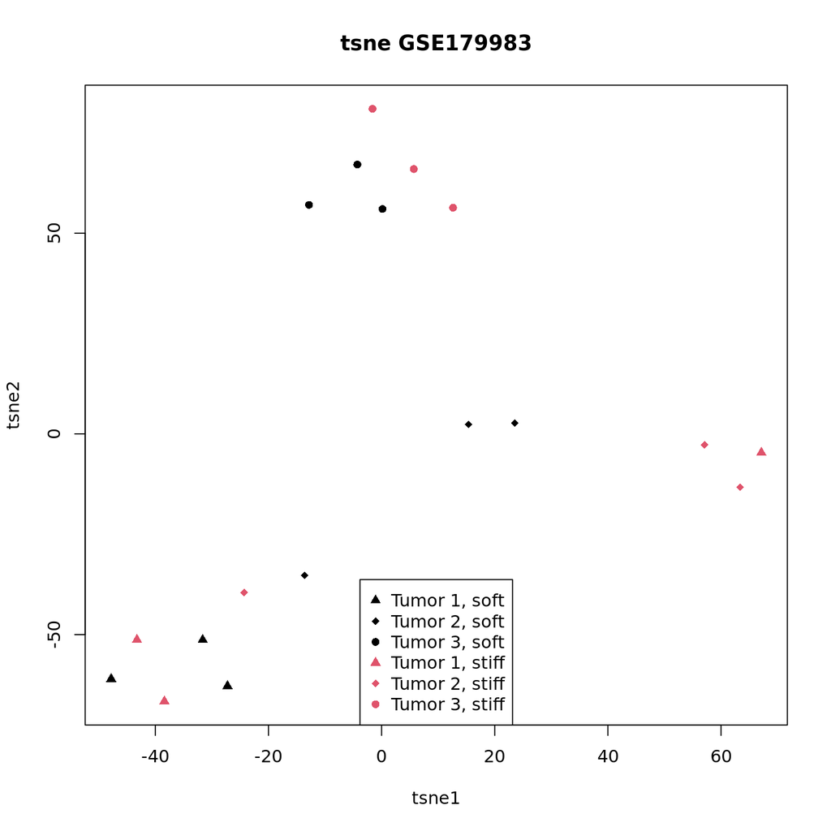

```r
set.seed(9999)
       tsne <- Rtsne(t(red),perplexity=4)
       plot(tsne$Y[,1],tsne$Y[,2], col=pData(GSE179983$log)$stroma,pch=c(rep(16,6),rep(17,6),rep(18,6)),xlab="tsne1", ylab ="tsne2", main="tsne GSE179983")
       legend("bottom",col=c(rep(1,3),rep(2,3)),pch=rep(c(17,18,16),2), legend = c("Tumor 1, soft","Tumor 2, soft","Tumor 3, soft","Tumor 1, stiff","Tumor 2, stiff","Tumor 3, stiff"))
```

The results do not improve the separation between stromal and stiff samples, with the exception of a small subgroup of samples from patient 1 and 2. Separation of samples from patient 3 is still evident enough. This could suggest that a lot of heterogeneity occurs among the cells in each condition and in each patient.

To further look into this hypotesis, an heatmap is built for a better visualization of the results, comparing differentially expressed genes of stromal stiff and soft samples. Heatmap is built by visualizing log expression of the genes on mean log expression ratio. To genes more expressed than the mean we assign red colors, while the opposite is true for genes with expression lower than the mean.

```r
    library(circlize)
        library(ComplexHeatmap)
    heat <- t(apply(exprs(GSE179983$log),1,function(x){x-mean(x)}))
        toc <- pData(GSE179983$log)
        toc <- toc[order(toc$patient),]
        toc <- toc[order(toc$stroma),]
        heat <- heat[,rownames(toc)]
        col_fun <- colorRamp2(c(-2, 0, 2), c("blue", "white", "red"))
        ha = rowAnnotation( genes=anno_text(hstiff, gp = gpar(fontsize = 1),show_name = TRUE))
        ht1 <- HeatmapAnnotation(Classification = anno_text(toc$patient, gp=gpar(fontsize=8,fill=c(rep("darkseagreen2",9),rep("coral3",9)))))
        ht2 <- Heatmap(heat[higher_in_stiff,], cluster_columns= FALSE, cluster_rows = FALSE, show_column_names=FALSE,show_row_names=FALSE, col=col_fun,top_annotation = ht1,heatmap_legend_param = list(col_fun = col_fun),left_annotation=ha)
        ht3 <- Heatmap(heat[which(match(rownames(heat),higher_in_stiff,nomatch=0)==0),],name = "Gene expression", cluster_columns=FALSE, cluster_rows = FALSE, show_row_names=FALSE,show_column_names=FALSE, col=col_fun,show_heatmap_legend=FALSE, heatmap_height=unit(5,"cm"))
```

```
## `use_raster` is automatically set to TRUE for a matrix with more than
## 2000 rows. You can control `use_raster` argument by explicitly setting
## TRUE/FALSE to it.
##
## Set `ht_opt$message = FALSE` to turn off this message.
```

```
## 'magick' package is suggested to install to give better rasterization.
##
## Set `ht_opt$message = FALSE` to turn off this message.
```

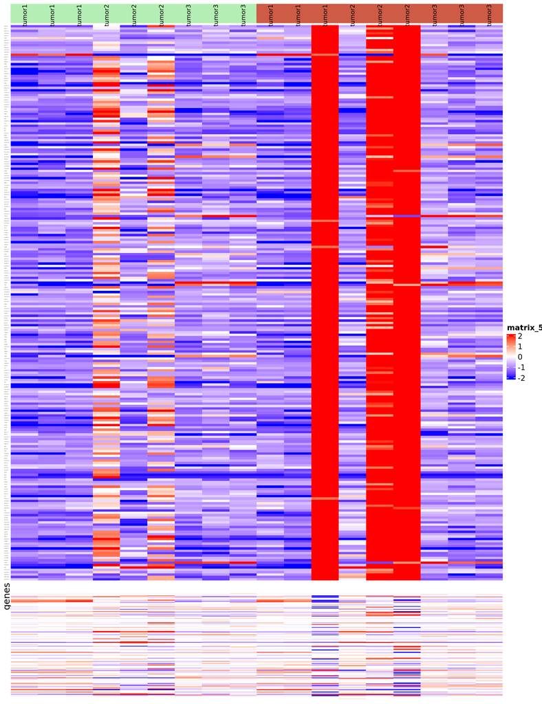

```r
    plot(ht2 %v% ht3, ht_gap=unit(0.6,"cm"))
```

By considering differentially expressed genes (on the top) we can see how the distinction between stiff and soft samples is not evident at a first glance. Samples from patient 2 seem to display more stiff features , even in the group of samples classified as soft. Such genes seem to be strongly overexpressed, while the remaining genes for those samples seem to be less expressed with respect of the mean of the cells. This could be explainable by a higher overall level of stiffnes, in which the cells completely prioritize stiffness related pathways over any other. On the other hand, cells with a lower expression of such genes display a higher overall expression of genes unrelated to stromal characteristics. Of note, we see that saturation of stiffness related genes in samples from color 2, makes cells with lower expression less scalable, interfering with the ability to see more subtle changes with an heatmap.

Relationships between samples can further be investigated by performing clustering on samples based on the differentially expressed genes. this is allowed thhanks to the hclust function of base R, which is used by the ComplexHeatmap package to build the plots by setting the cluster_columns parameter to true.

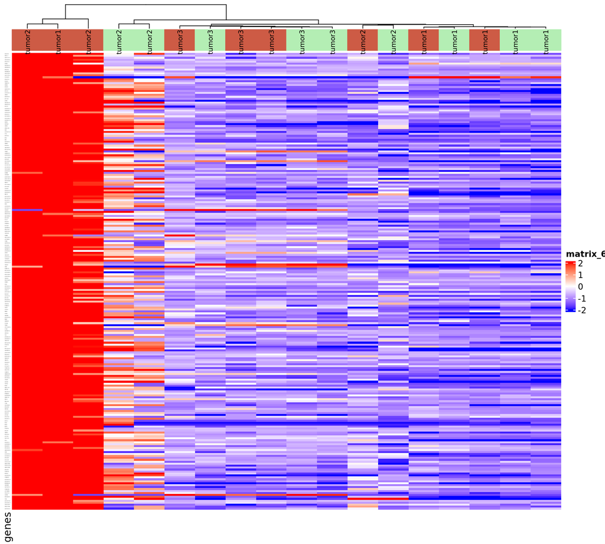

```r
ht2 <- Heatmap(heat[higher_in_stiff,], cluster_columns= TRUE, cluster_rows = FALSE, show_column_names=FALSE,show_row_names=FALSE, col=col_fun,top_annotation = ht1,heatmap_legend_param = list(col_fun = col_fun),left_annotation=ha)
plot(ht2)
```

After the clustering we see how samples from patients 2 and 1 seem to be closer with respect to samples from patient 3, which cluster all togheter in a single separate cluster, which is more similar to the samples of patient 1 and 2 with a lower stiffness. Again, we can see a definite cluster made by stiff samples of tumor 1 and 2.

Similarity between patients can also be evaluated by confronting overall gene expression between samples of different patients.

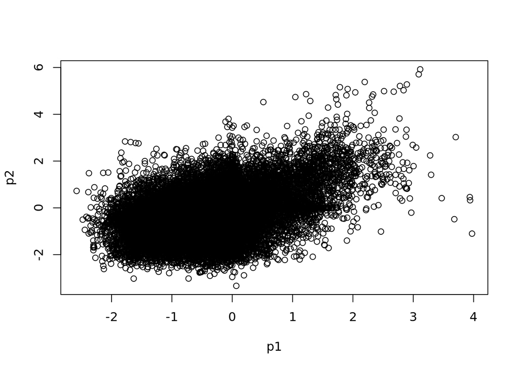

```r
    p1 <- apply(exprs(GSE179983$log),1,function(x){mean(x[which(pData(GSE179983$log)$patient=="tumor1" & pData(GSE179983$log)$stroma =="stiff")])-mean(x[which(pData(GSE179983$log)$patient=="tumor1"& pData(GSE179983$log)$stroma =="soft")])})
        p2 <- apply(exprs(GSE179983$log),1,function(x){mean(x[which(pData(GSE179983$log)$patient=="tumor2" & pData(GSE179983$log)$stroma=="stiff")])-mean(x[which(pData(GSE179983$log)$patient=="tumor2"& pData(GSE179983$log)$stroma =="soft")])})
        p3 <- apply(exprs(GSE179983$log),1,function(x){mean(x[which(pData(GSE179983$log)$patient=="tumor3" & pData(GSE179983$log)$stroma=="stiff")])-mean(x[which(pData(GSE179983$log)$patient=="tumor3" & pData(GSE179983$log)$stroma =="soft")])})
        plot(p1,p2)
```

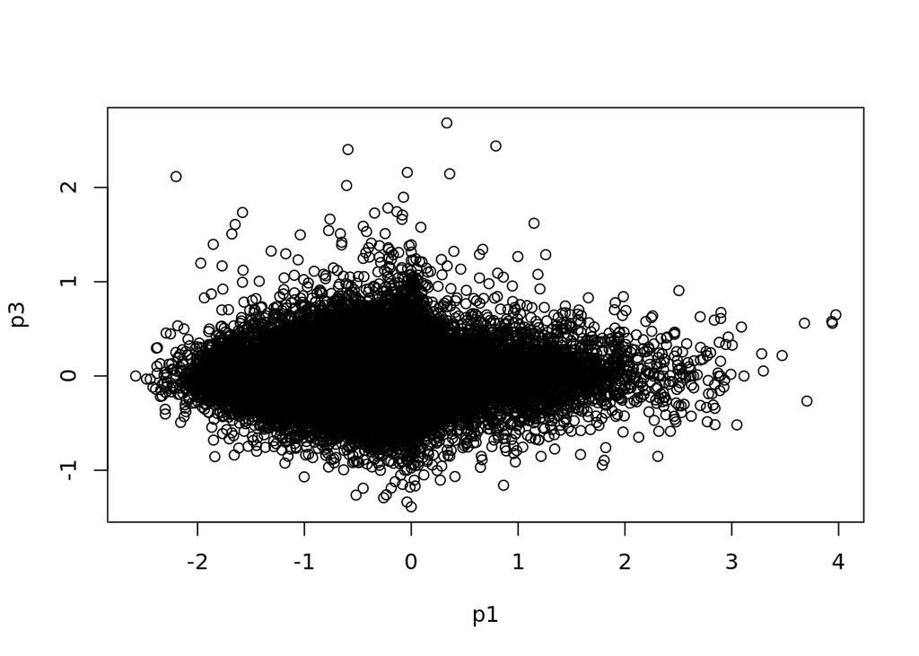

```r
        plot(p1,p3)
```

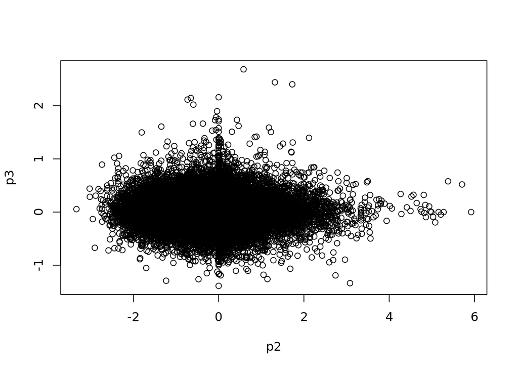

```r
        plot(p2,p3)
```

We see that relationship of mean value of tumor 3 with both tumor 1 and 2sample is all but linear. Insead, between samples from patient 1 and 2 there is a bit more coherence, with mean gene expression values for each gene having a higher degree of similarity.

Overall, these finding suggest that sample 3 might have different pathways in which it stromal stiffness is elicited, while we can work more on the comparisons of patient 1 and 2.

### 3.2.3 Functional enrichment

To identify biological function and features of the genes considered as differentially expressed, gene biotype is retrieved as to get an overall view of the identity of the genes.

```r
    table(fData(GSE179983$count)$Biotype[which(match(rownames(exprs(GSE179983$count)),higher_in_stiff,nomatch=0)>0)])
```

```
##
##                             lncRNA                              miRNA
##                                  6                                  1
##                           misc_RNA               processed_pseudogene
##                                  1                                148
##                     protein_coding                               rRNA
##                                 52                                  6
##                    rRNA_pseudogene                              snRNA
##                                  1                                  2
##   transcribed_processed_pseudogene     transcribed_unitary_pseudogene
##                                 11                                  1
## transcribed_unprocessed_pseudogene             unprocessed_pseudogene
##                                  1                                  4
```

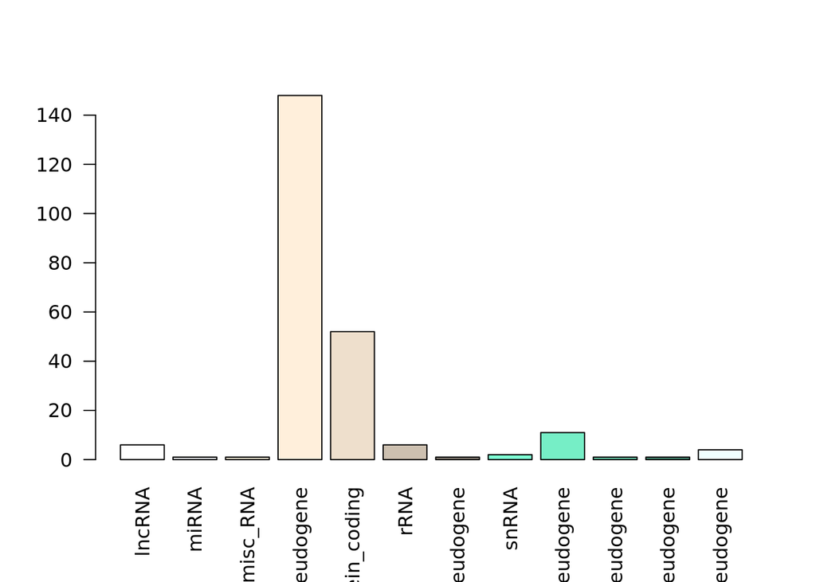

```r
        barplot(table(fData(GSE179983$count)$Biotype[which(match(rownames(exprs(GSE179983$count)),higher_in_stiff,nomatch=0)>0)]), las=2, col=colors(12))
```

As we can see, the majority of the features falls under the category of pseudogenes. This could be explained by the experimental procedure used to design the experiment. Samples were implanted onto PDX models. Stroma, in the case of PDX, is of murine origin when only cancer cells are transplanted. During the retrieve of the tissue for sequencing, and expecially since ths is a bulk analysis, stromal cells are not separated from cancer ones. Since sequencing data was only aligned to human genome, this could mean that pseudogenes are deriving from murine misaligned transcripts. Also, we see so many pseudogenes in the differential list due to the fact that the conditions in the differential expression analysis referexactly o the stromal composition. This would hence classify murine related stromal genes as genes with a great variability among the observed conditions.

To eliminate this bias, also as pseudogenes would not be mapped in repositories of human related gene features, before proceding into the functional enrichment analysis, pseudogenes were excluded.

A list of genes to be submitted for the functional analysis was generated and stored in the Results folder

```r
writeLines(fData(GSE179983$count)$Geneid[which(match(rownames(exprs(GSE179983$count)),higher_in_stiff,nomatch=0)>0 & !grepl("pseudogene",fData(GSE179983$count)$Biotype))],con="Results/differentially_expressed_list.txt")
```

Stating from [this list](https://github.com/CBenetti/Data_Analysis_exam/blob/main/Results/differentially_expressed_list.txt), entries were copied an pasted on the [g:Profiler website](https://biit.cs.ut.ee/gprofiler/), to perform gOST functional enrichment analysis. gOST is a tool which performs functional enrichment analysis on a series of different databases, inluding the more classical Gene Onthology one, but also other such as KEGG, as to get different kind of functional annotation on the gene.

# 4 Discussion